# R Guideline

# Getting Started with R

R 是一款專為統計分析和數據視覺化設計的強大且免費的軟件環境。  
它融合了統計包的便利性和編程的靈活性，廣泛應用於數據分析、機器學習和科學研究。  
R 提供了豐富的統計和圖形功能，使得用戶能夠進行複雜的數據操作和高質量的圖形輸出。

## 1. 安裝與R語言入門

教學檔案.pdf [下載點](https://drive.google.com/file/d/19KnlivREtSyZJWFhNvTUQkHfPrDvVnBn/view?usp=sharing)

## 2. 設定工作目錄 (working directory)

```r
# 獲取當前工作目錄，使用函數 getwd()
getwd()
```

```
## [1] "D:/college information/R_statistics"
```

```r
# 設置工作目錄，使用函數 setwd()
setwd("D:/college information/R_statistics")
getwd()
```

```
## [1] "D:/college information/R_statistics"
```

# Chapter 2

Chapter 2 - R markdown檔案 [下載點](https://drive.google.com/file/d/1JJa5F2DwkJ8Szw5mhVzfSns4wEOGj2JE/view?usp=sharing)

## 1. 安裝並載入套件&讀檔

```r
# 安裝openxlsx套件--套件只要安裝過一次即可
# install.packages("openxlsx")

# 載入套件
library(openxlsx)
```

### 將xlsx檔案讀入為dataframe

Chapter2.xlsx [下載點](https://docs.google.com/spreadsheets/d/16s-_ftmfIGnKEoCx1QC34F1N7DUQSILk/edit?usp=sharing&ouid=110553448349846752071&rtpof=true&sd=true)

```r
# 讀取檔案
file_path <- "D:/college information/R_statistics/Data Files/Chapter2.xlsx" # 更改成您要讀取之xlsx的路徑
sheet_name_1 <- "Marital_Status" #這裡輸入您要讀取的sheet的名稱
sheet_name_2 <- "MV_Houses" #這裡輸入您要讀取的sheet的名稱

# 使用read.xlsx函數讀取指定的工作表
marital.status.df <- read.xlsx(file_path, sheet = sheet_name_1)
mv.houses.df <- read.xlsx(file_path, sheet = sheet_name_2)
```

```r
# 顯示讀取的數據
print(marital.status.df)
```

```
##   Marital.Status 1960 2010
## 1        Married 0.71 0.52
## 2         Single 0.15 0.28
## 3       Divorced 0.05 0.14
## 4        Widowed 0.09 0.06
```

```r
print(mv.houses.df)
```

```
##    House.Price
## 1          430
## 2          520
## 3          460
## 4          475
## 5          670
## 6          521
## 7          670
## 8          417
## 9          533
## 10         525
## 11         538
## 12         370
## 13         530
## 14         525
```

[output cut: 22 more lines]

## 2. 繪製圓餅圖(Pie Chart)

### 繪製1960年婚姻狀態圓餅圖

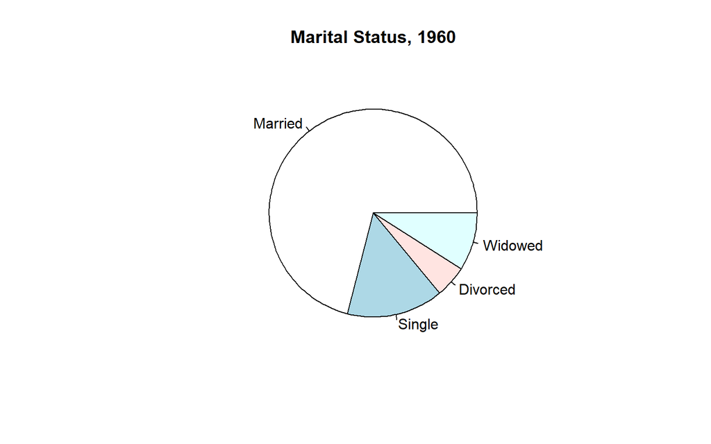

```r
# R語言的基本繪圖功能 -- pie()函數
pie(marital.status.df[, "1960"], # 選擇使用marital.status.df中1960年的資料繪製圓餅圖
    labels = marital.status.df[, "Marital.Status"], # 選擇用來分類的feature為婚姻狀況(Marital.Status)
    main = "Marital Status, 1960") # 設定圓餅圖的標題
```

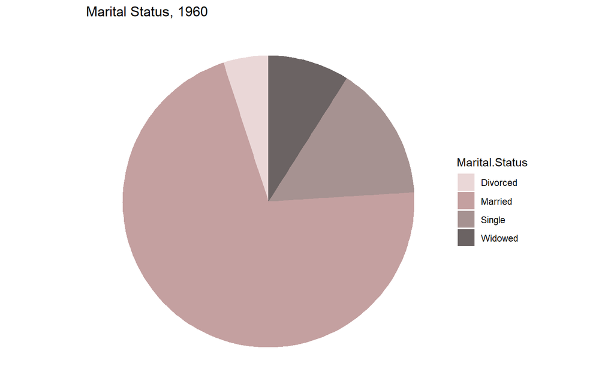

```r
# ggplot2套件繪圖功能
# 載入ggplot2套件
library(ggplot2)
# 設置圓餅圖的顏色
colors <- c("#EAD7D7", "#C4A0A0", "#A69291", "#6B6363")

# 使用 ggplot() 函數，設置資料來源為 marital.status.df，aes() 函數設置x與y變數，以及對應到不同顏色變量的屬性
ggplot(marital.status.df, aes(x = "", y = `1960`, fill = `Marital.Status`)) +
  # 使用 geom_bar() 函數繪製長條圖，設置寬度為1，stat = "identity" 表示使用資料的實際值
  geom_bar(width = 1, stat = "identity") +
  # 使用 coord_polar() 函數將長條圖轉換為圓餅圖，theta = "y" 表示以 y 軸為角度
  coord_polar(theta = "y") +
  # 使用 scale_fill_manual() 函數設置填充顏色
  scale_fill_manual(values = colors) +
  # 設值圓餅圖標題
  labs(title = "Marital Status, 1960") +
  # 將背景設定為空白
  theme_void() +
  # 將圖例設置在右側
  theme(legend.position = "right")
```

### 將兩個圓餅圖放在一起比較！

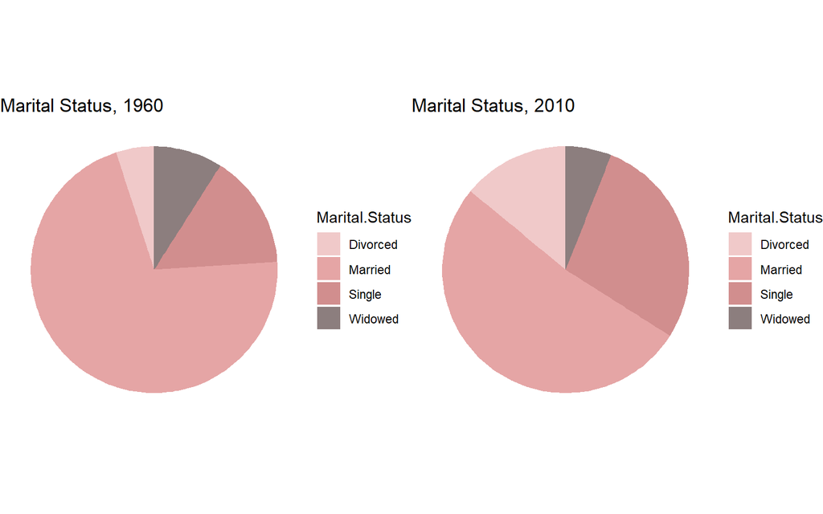

```r
library(ggplot2)
library(gridExtra)
# 設置圓餅圖的顏色
colors <- c("#F0C9C9", "#E5A5A5", "#D18E8E", "#8C7E7E")

# 繪製1960年的圓餅圖
plot_1960 <- ggplot(marital.status.df, aes(x = "", y = `1960`, fill = `Marital.Status`)) +
  geom_bar(width = 1, stat = "identity") +
  coord_polar(theta = "y") +
  scale_fill_manual(values = colors) +
  labs(title = "Marital Status, 1960") +
  theme_void() +
  theme(legend.position = "right")

# 繪製2010年的圓餅圖
plot_2010 <- ggplot(marital.status.df, aes(x = "", y = `2010`, fill = `Marital.Status`)) +
  geom_bar(width = 1, stat = "identity") +
  coord_polar(theta = "y") +
  scale_fill_manual(values = colors) +
  labs(title = "Marital Status, 2010") +
  theme_void() +
  theme(legend.position = "right")

# 使用 gridExtra 將兩個圓餅圖合再一起
combined_plot <- grid.arrange(plot_1960, plot_2010, ncol = 2)
```

## 3. 繪製長條圖(Bar Chart)

```r
# R語言的基本繪圖功能 -- barplot()
# 取出我們感興趣的第二列和第三列數據，使用as.matrix()函數將這些數值保存為列形式，然後使用轉置函數t()將列轉換為行
marital.status.matrix.t <- t(as.matrix(marital.status.df[, 2:3]))

# 顯示轉置後的數據
print(marital.status.matrix.t)
```

```
##         1    2    3    4
## 1960 0.71 0.15 0.05 0.09
## 2010 0.52 0.28 0.14 0.06
```

```r
# 使用colnames()函數為轉置後的矩陣中的每一列命名列名
colnames(marital.status.matrix.t) <- marital.status.df[, 'Marital.Status']

# 這樣轉置後的矩陣就有列名了
print(marital.status.matrix.t)
```

```
##      Married Single Divorced Widowed
## 1960    0.71   0.15     0.05    0.09
## 2010    0.52   0.28     0.14    0.06
```

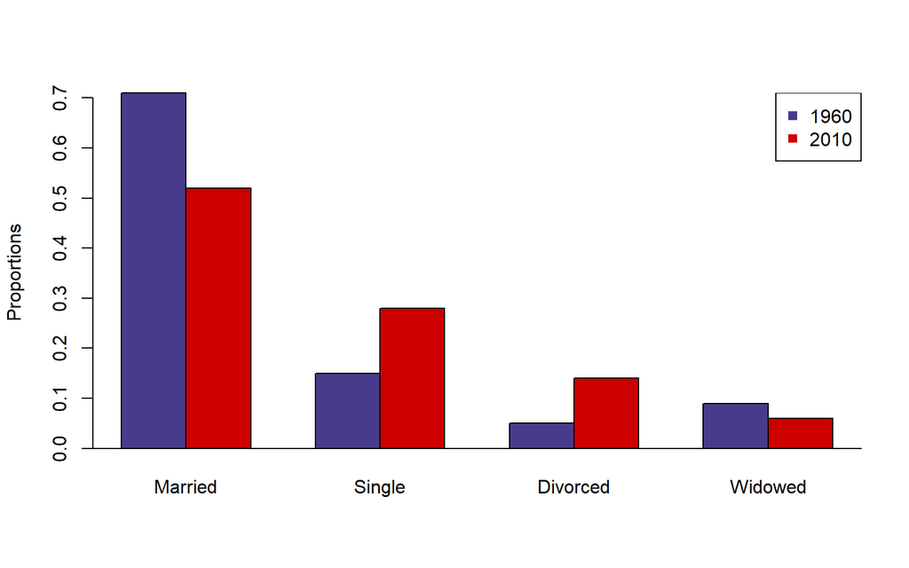

```r
# 使用 barplot() 函數創建一個長條圖
barplot(marital.status.matrix.t, # 傳入的數據
        beside = TRUE, # 指定條形圖是並列顯示，而不是堆疊顯示
        ylab = 'Proportions', # 設定y軸標籤
        col = c('slateblue4', 'red3')) # 設定不同類別的顏色，此處共設定兩種顏色
abline(h=0) # 在當前的圖形中添加一條水平於 y=0 的直線（也就是x軸）
legend("topright", c("1960","2010"), pch=15, col=c("slateblue4","red3")) # 設置圖例位置、標籤、字體大小與顏色
```

## 4. 繪製直方圖(Histogram)

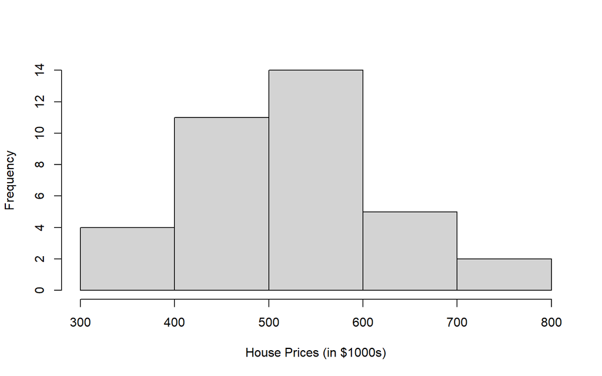

```r
# R語言的基本繪圖功能 -- hist() 函數
hist(mv.houses.df[, "House.Price"], # 使用mv.houses.df 的 House.Price 欄位作為輸入資料
     breaks = 5, # 指定直方圖中的分組數量
     xlab = "House Prices (in $1000s)", # 設置 x 軸的標籤
     main = NULL) # 設置圖表的標題，這裡並無設置，因此為NULL
```

## 5. 繪製次數多邊圖(Polygon)

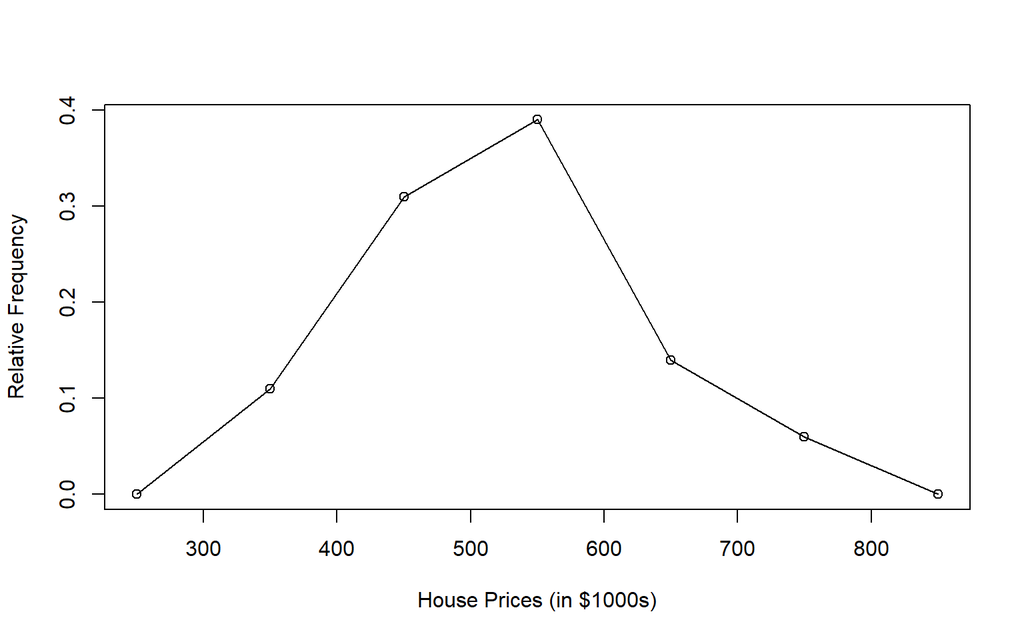

```r
# 輸入中點向量和相對頻率數據
midpoint <- seq(from = 250, to = 850, by = 100)
relative.frequency <- c(0, 0.11, 0.31, 0.39, 0.14, 0.06, 0)

# R語言的基本繪圖功能 -- plot()
plot(relative.frequency ~ midpoint, # 將 relative.frequency（y 軸）繪製為與 midpoint（x 軸）的函數關係
     ylab = "Relative Frequency",  # 設置了 y 軸的標籤為 "Relative Frequency"
     xlab = "House Prices (in $1000s)") # 設置 x 軸的標籤為 "House Prices (in $1000s)"
lines(relative.frequency ~ midpoint) # 將繪製的點進行連線
```

## 6. 繪製累積百分比曲線圖(Ogive)

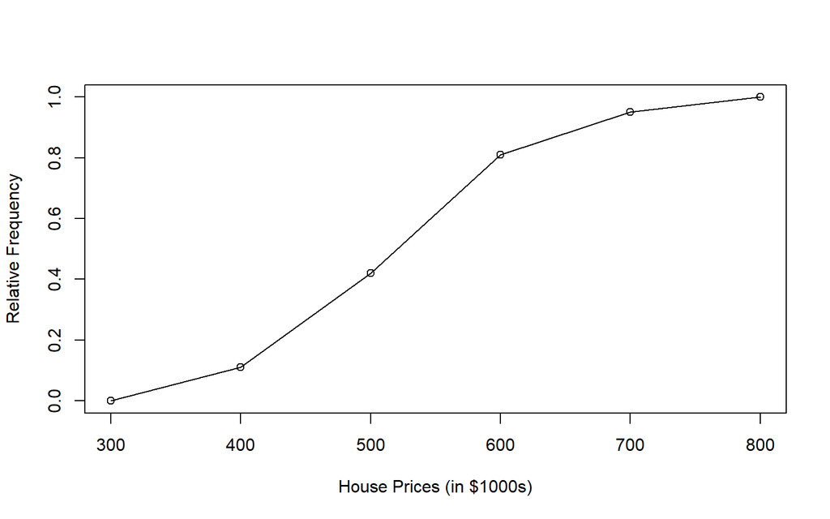

```r
# 輸入房屋價格區間與相對頻率有關的資料
midpoint <- seq(from = 300, to = 800, by = 100)
relative.frequency <- c(0, 0.11, 0.42, 0.81, 0.95, 1) # 定義成一個向量

# R語言的基本繪圖功能 -- plot()
plot(relative.frequency ~ midpoint, # 將 relative.frequency（y 軸）繪製為與 midpoint（x 軸）的函數關係
     ylab = "Relative Frequency", # 設置了 y 軸的標籤為 "Relative Frequency"
     xlab = "House Prices (in $1000s)") # 設置 x 軸的標籤為 "House Prices (in $1000s)"
lines(relative.frequency ~ midpoint)  # 將繪製的點進行連線
```

## 7. 繪製散佈圖(Scatterplot)

```r
# 輸入並且設定資料
edinc.matrix <- rbind(c(3,45),c(4,56), c(6,85), c(2,35),
                      c(5,55),c(4,48), c(8,100), c(0,38))
colnames(edinc.matrix) <- c("education", "income")
edinc.matrix
```

```
##      education income
## [1,]         3     45
## [2,]         4     56
## [3,]         6     85
## [4,]         2     35
## [5,]         5     55
## [6,]         4     48
## [7,]         8    100
## [8,]         0     38
```

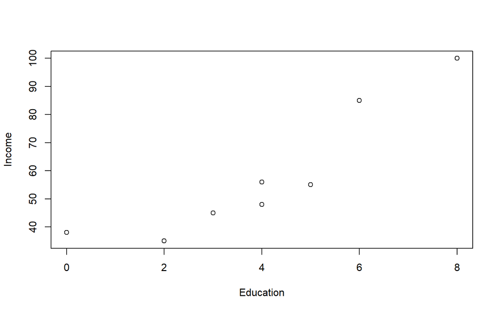

```r
# R語言的基本繪圖功能 -- plot()
plot(edinc.matrix, ylab = "Income", xlab = "Education")
```

# Chapter 3

Chapter 3 - R markdown檔案 [下載點](https://drive.google.com/file/d/1JlP8sGDQN3GHUixnh8TqjGmZJ-r2wrhZ/view?usp=share_link)

**在這個章節，我們使用的資料集是「Fund_Returns」:** Fund_Returns.xlsx [下載點](https://docs.google.com/spreadsheets/d/1rKbstviJN1Rppem3h56P1kraNQOcpxC-/edit?usp=sharing&ouid=110553448349846752071&rtpof=true&sd=true)

## 1. 載入套件&讀檔

```r
# 載入套件
library(openxlsx)

# 讀取檔案
file_path <- "D:/college information/R_statistics/Data Files/Fund_Returns.xlsx" # 更改成您要讀取之xlsx的路徑

# 使用read.xlsx函數讀取
fund.returns.df <- read.xlsx(file_path)

# 印出資料集
print(fund.returns.df)
```

```
##    Year Metals Income
## 1  2000  -7.34   4.07
## 2  2001  18.33   6.52
## 3  2002  33.35   9.38
## 4  2003  59.45  18.62
## 5  2004   8.09   9.44
## 6  2005  43.79   3.12
## 7  2006  34.30   8.15
## 8  2007  36.13   5.44
## 9  2008 -56.02 -11.37
## 10 2009  76.46  31.77
```

## 2. 獲取基本數據摘要

```r
# 使用 fund.returns.df 展示如何獲取一個dataframe的數據統計摘要
(summary(fund.returns.df))
```

```
##       Year          Metals           Income
##  Min.   :2000   Min.   :-56.02   Min.   :-11.370
##  1st Qu.:2002   1st Qu.: 10.65   1st Qu.:  4.412
##  Median :2004   Median : 33.83   Median :  7.335
##  Mean   :2004   Mean   : 24.65   Mean   :  8.514
##  3rd Qu.:2007   3rd Qu.: 41.88   3rd Qu.:  9.425
##  Max.   :2009   Max.   : 76.46   Max.   : 31.770
```

```r
# 此外，R 具有許多可以獨立生成這些測量值的函數。
# 例如，函數 mean()、median()、min()、max()、sd() 和 var() 分別提供均值、中位數、最小值、最大值、標準差和方差。
# 假設想找到 Fund_Return 數據中 Metals 基金的均值，可以輸入以下命令：
mean(fund.returns.df[, 'Metals'])
```

```
## [1] 24.654
```

## 3. 建立箱型圖(Box Plot)

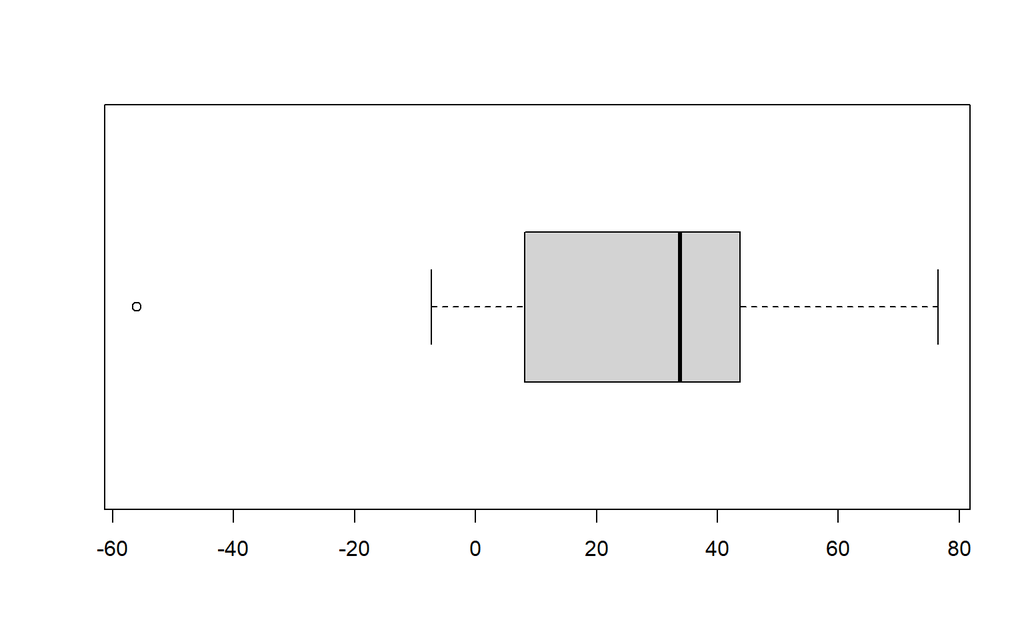

```r
# 使用 boxplot() 函數與fund.returns.df數據框來創建 Metals 的水平箱型圖
# 方法一
boxplot(fund.returns.df[, 'Metals'], horizontal = TRUE)
```

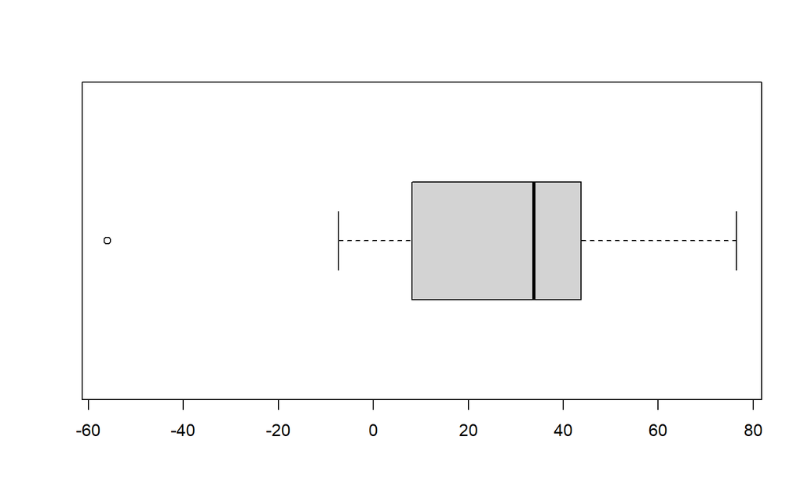

```r
# 方法二
boxplot(fund.returns.df$Metals, # 選擇數據
        horizontal = TRUE, # 生成水平箱型圖
        main = NULL, # 設置圖表的標題
        xlab = NULL) # 設置 X 軸的標籤
```

## 4. 計算共變異數和相關係數

### 計算共變異數(Covariance)

```r
# 計算共變異數矩陣
cov_matrix <- cov(fund.returns.df)
print(cov_matrix)
```

```
##             Year    Metals     Income
## Year    9.166667   11.5500   3.702222
## Metals 11.550000 1378.6048 351.727382
## Income  3.702222  351.7274 122.484004
```

### 計算相關係數(Correlation Coefficients)

```r
# 計算相關矩陣
cor_matrix <- cor(fund.returns.df)
print(cor_matrix)
```

```
##             Year    Metals    Income
## Year   1.0000000 0.1027440 0.1104885
## Metals 0.1027440 1.0000000 0.8559464
## Income 0.1104885 0.8559464 1.0000000
```

# Chapter 5

Chapter 5 - R markdown檔案 [下載點](https://drive.google.com/file/d/1sEUBeMeWbyOTpv6esoBX8NVxV3d-2lCX/view?usp=share_link)

## 1.二項分布

**使用 dbinom(x, n, p) 函數來計算二項隨機變數 X 取特定值 x 的機率**  
**其中 x 是成功次數，n 是試驗次數，p 是成功的機率**

```r
# 課本範例5.9a
# 因為 X 是一個二項隨機變數，且 n = 100，p = 0.047，我們可以通過輸入以下程式碼來找到 P(X = 5):
dbinom(5, 100, 0.047)
```

```
## [1] 0.1782534
```

## 2.卜瓦松分布

```r
# 課本範例5.11a
# 因為 X 是一個泊松隨機變數，且 μ = 114，我們可以通過輸入以下程式碼來找到 P(X ≤ 100):
ppois(100, 114)
```

```
## [1] 0.1012059
```

## 3.超幾何分布

**使用 dhyper(x, S, N − S, n) 函數來計算超幾何隨機變數 X 取特定值 x 的機率**  
**其中 x 是樣本中的成功次數，S 是總體中的成功次數，N 是總體大小（所以 N − S 是失敗次數），n 是樣本大小**

```r
# 課本範例5.12a
# 因為 X 是一個超幾何隨機變數，且 S = 2，N = 20（所以 20 − 2 = 18），以及 n = 5，我們可以通過輸入以下程式碼來找到 P(X = 1)：
dhyper(1, 2, 18, 5)
```

```
## [1] 0.3947368
```

# Chapter 6

## 1.均勻分布

**使用 punif(x, a, b, lower.tail = FALSE or TRUE) 函數來計算連續均勻隨機變數 X 在區間 [a, b] 內取某個範圍值的機率**  
**其中 x 是我們希望評估機率的值，a 是連續均勻分布的下界，b 是上界**  
**對於函數中的最後一個參數，如果我們輸入 lower.tail = FALSE，則 R 返回 P(X>x)；如果輸入 lower.tail = TRUE，則 R 返回 P(X≤x)**

```r
# 課本範例6.1b
# 因為 X 是一個連續均勻隨機變數，且 a = 2500 和 b = 5000，我們可以通過輸入以下程式碼來找到 P(X>4000)：
punif(4000, 2500, 5000, lower.tail = FALSE)
```

```
## [1] 0.4
```

## 2.常態分佈

**使用 pnorm(x, μ, σ, lower.tail = FALSE or TRUE) 函數來計算常態隨機變數 X 小於或等於 x 或大於 x 的機率**  
**其中 x 是我們希望評估機率的值，μ 是總體平均數，σ 是總體標準差**  
**對於函數中的最後一個參數，如果輸入 lower.tail = FALSE，則 R 返回 P(X>x)；如果輸入 lower.tail = TRUE，則 R 返回 P(X≤x)**

```r
# 課本範例6.8a
# 因為X 是一個正態隨機變數，且 μ = 12 和 σ = 3.2，我們可以通過輸入以下程式碼來找到 P(X>20)
pnorm(20, 12, 3.2, lower.tail = FALSE)
```

```
## [1] 0.006209665
```

### 逆轉換

**使用 qnorm(probability, μ, σ) 函數來找到對應於給定累積正態機率的特定 x 值**  
**其中 probability 是給定的累積機率，μ 是總體平均數，σ 是總體標準差**

```r
# 課本範例6.8c
# 希望找到 x 使得 P(X≤x)=0.90，且 μ = 12 和 σ = 3.2，我們可以通過輸入以下程式碼來找到該 x 值
qnorm(0.90, 12, 3.2)
```

```
## [1] 16.10097
```

## 3.指數分佈

**使用 pexp(x, λ, lower.tail = FALSE or TRUE) 函數來計算指數隨機變數 X 小於或等於 x 或大於 x 的機率**  
**其中 x 是我們希望評估機率的值，λ 是速率參數**  
**對於函數中的最後一個參數如果我們輸入 lower.tail = FALSE，則 R 返回 P(X>x)；如果輸入 lower.tail = TRUE，則 R 返回 P(X≤x)**

```r
# 課本範例6.9b
# 因為 X 是一個指數隨機變數，且 λ = 1/25，我們可以通過輸入以下程式碼來找到 P(X>60)
pexp(60, rate = 1/25, lower.tail = FALSE)
```

```
## [1] 0.09071795
```

## 4.對數常態分布

**使用 plnorm(y, μ, σ) 函數來計算對數常態隨機變數 Y 小於或等於 y 的機率**  
**其中 y 是我們希望評估機率的值，μ 是潛在正態分布的平均數，σ 是潛在正態分布的標準差**

```r
# 課本範例6.11a
# 因為 Y 是一個對數正態隨機變數，且 μ = 5 和 σ = 1.2，我們可以通過輸入以下程式碼來找到 P(Y≤200)
plnorm(200, 5, 1.2)
```

```
## [1] 0.598164
```

### 逆轉換

**使用 qlnorm(probability, μ, σ) 函數來找到對應於給定累積對數正態機率的特定 y 值**  
**其中 probability 是給定的累積機率，μ 是潛在正態分布的平均數，σ 是潛在正態分布的標準差**

```r
# 課本範例6.11b
# 因為我們希望找到 y 使得 P(Y≤y)=0.90，且 μ = 5 和 σ = 1.2，我們可以通過輸入以下程式碼來找到該 y 值
qlnorm(0.90, 5, 1.2)
```

```
## [1] 690.808
```

# Chapter 7

Chapter7.xlsx [下載點](https://docs.google.com/spreadsheets/d/1jitup-4jbbFoG0NeH8cqt6HqMdsfd0WC/edit?usp=share_link&ouid=110553448349846752071&rtpof=true&sd=true)

## 1.安裝、載入套件&讀檔

```r
## 安裝套件
# install.packages(c("openxlsx", "qcc"))
## 載入套件
library(openxlsx)
library(qcc)

# 讀取檔案
file_path <- "D:/college information/R_statistics/Data Files/Chapter7.xlsx" # 更改成您要讀取之xlsx的路徑
sheet_name_1 <- "Lux_Hotel" #這裡輸入您要讀取的sheet的名稱

# 使用read.xlsx函數讀取指定的工作表
lux.hotel.df <- read.xlsx(file_path, sheet = sheet_name_1)

print(lux.hotel.df)
```

```
##               Shift Sample Wait.Time.(in.seconds)  X4  X5  X6 Sample.Mean
## 1              <NA>      1                     67  48  52  71          60
## 2              <NA>      2                     57  68  60  66          63
## 3          Shift 1:      3                     37  41  60  41          45
## 4  12:00 am-6:00 am      4                     83  59  49  66          64
## 5              <NA>      5                     82  63  64  83          73
## 6              <NA>      6                     87  53  66  69          69
## 7              <NA>      7                     98 100 122 108         107
## 8              <NA>      8                    125 121 120 128         124
## 9          Shift 2:      9                    116 104  96 111         107
## 10 6:00 am-12:00 pm     10                    100 123 102  90         104
## 11             <NA>     11                    123  94 128 113         114
## 12             <NA>     12                    107 105 113 106         108
## 13             <NA>     13                     59  41  37  41          44
## 14             <NA>     14                     27  42  39  49          39
## 15         Shift 3:     15                     72  81  62  67          71
## 16 12:00 pm-6:00 pm     16                     50  46  30  45          43
## 17             <NA>     17                     17  46  53  24          35
## 18             <NA>     18                     34  37  34  47          38
## 19             <NA>     19                      6  11   8   9           9
## 20             <NA>     20                     10   8  10   9           9
## 21         Shift 4:     21                     11   7  14   7          10
## 22 6:00 pm-12:00 am     22                      8   9   9  12          10
## 23             <NA>     23                      9  12   9  14          11
## 24             <NA>     24                      5   8  15  11          10
```

## 2.生成隨機樣本

**（重現範例7.1）**

### 使用抽樣

#### A. 使用 sample() 函數

```r
# 從 20,000 名學生中隨機選擇 100 名學生
sample(1:20000, 100, replace = FALSE)
```

```
##   [1] 10519 14361 15350  9326 15467  7674  6021 12489  5460   492 10459  9881
##  [13] 11955 17313  7375 16947  8012 13400 19320  2080 13349 13298 14226 10374
##  [25]  5401 16617 15440 18350 17769  5357  5005 16686   564  7077 12403  7622
##  [37] 10786  2167  4717  3036 14421 10572 13005  9436  2038 16136  6470  9253
##  [49]  4809  2604 14499  6157  4201 10475  9376 16139  9313 11870  4312 19468
##  [61]  5905 10286  6494 14487  4129 10896  9917  8880  2766 18877 12853 13023
##  [73] 11970  7960  7412  9024  6486 12236 18251 10599 16175   147 18427 12133
##  [85] 17776 14901  9791  1753 14260 11470 17741 18492 14900 14988   337 16828
##  [97] 17118  4579   928 15926
```

#### B. 使用 sample.int() 函數

```r
# 使用 replace = FALSE 因為我們希望不放回抽樣
sample.int(20000, 100, replace = FALSE)
```

```
##   [1] 12266  6280  9742  3174 14405 10654 10442 16580  4925  9269  5736  2597
##  [13] 19021  7618 18417  7549 12248  4416  3694 10428 13214  3659  7989 12714
##  [25] 10794 10171   154  8556 16480 17961  4944 14246 16571 14877   795  1023
##  [37] 16059  2680  3442 12839 16763 15422 13985  8803  9403  1636  4567 13045
##  [49]  8910  4785  3652  5345  4714 14756 13901  6423   821  5831  3243  6876
##  [61] 13432  9311  2635 14765  5822 13347  4961 12621  7122  7830 13811  6919
##  [73] 16737 12708 12928  7339   651  3487 13439  9649 15877  8659  1838 15636
##  [85]  4498 16305  2835 15026 11309  6699  7531  4839 19291 16695  2917 14586
##  [97] 12654   764  2473 17745
```

### 從分布中生成樣本

#### A. 使用 runif() 函數從均勻分布中生成樣本

```r
values <- runif(100, 1, 20000)
values
```

```
##   [1] 13286.02642  3735.18446 19632.01925 17099.20881  1545.20072  5505.77738
##   [7] 16585.17433 18351.60630   872.17318 13671.62583  3730.61144 10802.60993
##  [13] 18579.98291  7739.43453 11004.39670 16393.74408  6709.76732  4850.65139
##  [19] 18146.08352 14857.94580   417.03105 11073.18580  2814.50801   426.41148
##  [25] 18236.69058 15554.48804 12669.95798  8941.74735 18474.64918 18136.39507
##  [31] 18406.45393  2520.59487 15569.09187 17838.33776 10674.78141 15289.50753
##  [37] 17474.33376 14107.43155  8215.88081 11546.97097 13029.60221 12893.02644
##  [43] 15296.53737  4146.97924  9491.31719 12779.46327   487.00302  2249.77027
##  [49]  4109.47229  3638.10104 16910.61192 10956.28164  2016.05582 11395.34947
##  [55] 11741.47851  6328.93638  4807.50935  8038.33147 14293.86206  6057.82957
##  [61] 10740.69904 10890.64068 14925.80313 16330.64280  3348.70000   633.10573
##  [67]  2342.70557    21.92103  1555.12522 14813.16667 14712.40882 18319.79705
##  [73] 10211.79022  6762.52375  4803.90447 15621.99246    10.71586 11093.72710
##  [79] 11464.77033  7472.30676  9474.22117  4116.49766  3992.29497 15210.25246
##  [85] 14525.84521   880.39569  5816.55739  7831.62101  9735.55634  1449.50749
##  [91]  4860.56187 10027.91234  8978.94941 17958.83906 16164.39244  7312.97328
##  [97] 17058.07591 17044.13963 14867.97176 18588.66035
```

#### B. 將生成的值四捨五入到整數，獲得隨機整數樣本

```r
round(values, 0)
```

```
##   [1] 13286  3735 19632 17099  1545  5506 16585 18352   872 13672  3731 10803
##  [13] 18580  7739 11004 16394  6710  4851 18146 14858   417 11073  2815   426
##  [25] 18237 15554 12670  8942 18475 18136 18406  2521 15569 17838 10675 15290
##  [37] 17474 14107  8216 11547 13030 12893 15297  4147  9491 12779   487  2250
##  [49]  4109  3638 16911 10956  2016 11395 11741  6329  4808  8038 14294  6058
##  [61] 10741 10891 14926 16331  3349   633  2343    22  1555 14813 14712 18320
##  [73] 10212  6763  4804 15622    11 11094 11465  7472  9474  4116  3992 15210
##  [85] 14526   880  5817  7832  9736  1450  4861 10028  8979 17959 16164  7313
##  [97] 17058 17044 14868 18589
```

## 3.構建 x̄ 圖

### A. 從 lux.hotel.df 數據文件中提取等待時間的列

```r
wait.times <- lux.hotel.df[, 3:6]
head(wait.times)
```

```
##   Wait.Time.(in.seconds) X4 X5 X6
## 1                     67 48 52 71
## 2                     57 68 60 66
## 3                     37 41 60 41
## 4                     83 59 49 66
## 5                     82 63 64 83
## 6                     87 53 66 69
```

### B. 使用 qcc 函數創建 x̄ 圖

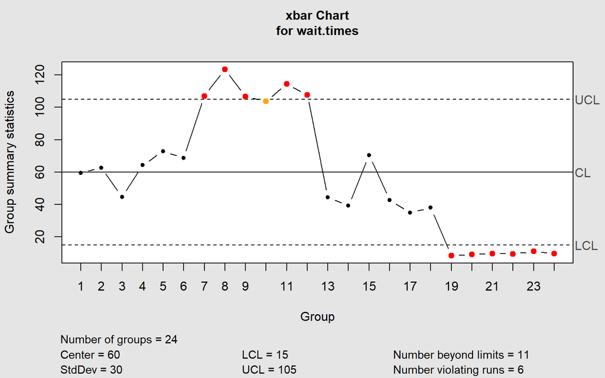

```
## List of 11
##  $ call      : language qcc(data = wait.times, type = "xbar", center = 60, std.dev = 30, nsigmas = 3)
##  $ type      : chr "xbar"
##  $ data.name : chr "wait.times"
##  $ data      : num [1:24, 1:4] 67 57 37 83 82 87 98 125 116 100 ...
##   ..- attr(*, "dimnames")=List of 2
##  $ statistics: Named num [1:24] 59.5 62.8 44.8 64.2 73 ...
##   ..- attr(*, "names")= chr [1:24] "1" "2" "3" "4" ...
##  $ sizes     : Named int [1:24] 4 4 4 4 4 4 4 4 4 4 ...
##   ..- attr(*, "names")= chr [1:24] "1" "2" "3" "4" ...
##  $ center    : num 60
##  $ std.dev   : num 30
##  $ nsigmas   : num 3
##  $ limits    : num [1, 1:2] 15 105
##   ..- attr(*, "dimnames")=List of 2
##  $ violations:List of 2
##  - attr(*, "class")= chr "qcc"
```

```r
# 創建 x̄ 圖
qcc(wait.times, type = "xbar", center = 60, std.dev = 30, nsigmas = 3)
```

# Chapter 8

Chapter8.xlsx [下載點](https://docs.google.com/spreadsheets/d/1irH4-_QJqi5AL4mJRuc-se3b9fUuP9fa/edit?usp=share_link&ouid=110553448349846752071&rtpof=true&sd=true)

## 1.安裝、載入套件&讀檔

```r
# 安裝套件
# install.packages(c("openxlsx", "BSDA"))

# 載入套件
library(openxlsx)
library(BSDA)

# 讀取檔案
file_path <- "D:/college information/R_statistics/Data Files/Chapter8.xlsx" # 更改成您要讀取之xlsx的路徑
sheet_name_1 <- "Hockey_Pucks" #這裡輸入您要讀取的sheet的名稱
sheet_name_2 <- "Lottery" #這裡輸入您要讀取的sheet的名稱

# 使用read.xlsx函數讀取指定的工作表
hockey.pucks.df <- read.xlsx(file_path, sheet = sheet_name_1)
lottery.df <- read.xlsx(file_path, sheet = sheet_name_2)
```

```r
# 用head() 函數用於查看資料的前幾行，默認值為6 行
head(hockey.pucks.df)
```

```
##   Weight
## 1  162.2
## 2  159.8
## 3  163.6
## 4  166.2
## 5  166.0
## 6  167.3
```

```r
# 調整查看的行數為前7行
head(lottery.df, 7)
```

```
##   Expenditures
## 1          790
## 2          594
## 3          899
## 4         1105
## 5         1090
## 6         1197
## 7          413
```

### 對dataframe使用summary()函數

```r
summary(hockey.pucks.df)
```

```
##      Weight
##  Min.   :152.2
##  1st Qu.:162.2
##  Median :166.2
##  Mean   :166.7
##  3rd Qu.:171.1
##  Max.   :188.1
```

```r
summary(lottery.df)
```

```
##   Expenditures
##  Min.   : 334.0
##  1st Qu.: 685.0
##  Median : 833.0
##  Mean   : 841.9
##  3rd Qu.: 994.5
##  Max.   :1325.0
```

## 2. σ 已知時， 估計 μ

```r
# 使用 hockey.pucks.df 數據文件來說明如何在已知 σ 的情況下估計 μ 的方法
# 使用 BSDA 包中的 z.test() 函數
# 將總體標準差 sigma.x 設置為 7.5，將信賴區間 conf.level 設置為 0.92

# 執行 z 檢驗
z.test(hockey.pucks.df[, "Weight"], sigma.x = 7.5, conf.level = 0.92)
```

```
##
##  One-sample z-Test
##
## data:  hockey.pucks.df[, "Weight"]
## z = 198.81, p-value < 2.2e-16
## alternative hypothesis: true mean is not equal to 0
## 92 percent confidence interval:
##  165.2433 168.1792
## sample estimates:
## mean of x
##  166.7113
```

## 3. σ 未知時， 估計 μ

```r
# 使用 lottery.df 數據文件來說明如何在未知 σ 的情況下估計 μ 的方法
# 使用 BSDA 包中的 t.test() 函數
# 信賴區間 conf.level 的默認值為 0.95，但為了讓程式碼更清楚，在這裡仍然明確寫入程式碼中

# 執行 z 檢驗
t.test(lottery.df[, "Expenditures"], conf.level = 0.95)
```

```
##
##  One Sample t-test
##
## data:  lottery.df[, "Expenditures"]
## t = 38.772, df = 99, p-value < 2.2e-16
## alternative hypothesis: true mean is not equal to 0
## 95 percent confidence interval:
##  798.8522 885.0278
## sample estimates:
## mean of x
##    841.94
```

## 4.估計 p

**使用範例8.7來說明如何估計 p**

### A. 計算樣本比例

```r
# 設定成功次數 successes 為 7，試驗次數 trials 為 25，然後通過將 successes 除以 trials 來獲得樣本比例
successes <- 7
trials <- 25
pbar <- successes / trials
```

### B. 計算臨界值和誤差範圍

```r
# 使用 qnorm() 函數來找到臨界值 z
# 由於我們希望信賴區間為 90%，因此 α = 1 − 0.90 =0.10，我們使用 α/2 = 0.05
z <- -qnorm(0.05)
# 計算誤差範圍
margin.of.error <- z * sqrt(pbar * (1 - pbar) / trials)
```

### C. 計算信賴區間

```r
# 通過從樣本比例中加上和減去誤差範圍來找到信賴區間
conf.interval <- c(pbar - margin.of.error, pbar + margin.of.error)
conf.interval
```

```
## [1] 0.1322925 0.4277075
```

# Chapter 9 Hypothesis Testing

Chapter9.xlsx [下載點](https://docs.google.com/spreadsheets/d/1KyHUSv7p4YvgKpVaQGBZrQhVcQZd0Xyh/edit?usp=share_link&ouid=110553448349846752071&rtpof=true&sd=true)

## 1.安裝、載入套件&讀檔

```r
# 安裝套件
# install.packages(c("openxlsx", "BSDA"))

# 載入套件
library(openxlsx)
library(BSDA)

# 讀取檔案
file_path <- "D:/college information/R_statistics/Data Files/Chapter9.xlsx" # 更改成您要讀取之xlsx的路徑
sheet_name_1 <- "Debit_Spending" #這裡輸入您要讀取的sheet的名稱
sheet_name_2 <- "MI_Life" #這裡輸入您要讀取的sheet的名稱

# 使用read.xlsx函數讀取指定的工作表
debit.spending.df <- read.xlsx(file_path, sheet = sheet_name_1)
mi.life.expectancy.df <- read.xlsx(file_path, sheet = sheet_name_2)
```

### 用head()查看dataframe前六筆資料

```r
head(debit.spending.df)
```

```
##   Spending
## 1     7960
## 2     7700
## 3     7727
## 4     7704
## 5     8543
## 6     7661
```

```r
head(mi.life.expectancy.df)
```

```
##    Age
## 1 76.4
## 2 76.0
## 3 76.7
## 4 75.9
## 5 79.5
## 6 83.3
```

## 2. σ 已知時， 檢驗 μ

#### I.假設

```
H_0(虛無假設):  μ = 8000
H_A(對立假設) : μ < 8000 (左尾檢定)
```

#### II. 設定 α 值

```
α = 0.05
```

#### III. 計算z統計量

```r
# 使用 debit.spending.df 數據文件來說明如何在已知 σ 的情況下檢驗 μ 的方法
# 使用 BSDA 包中的 z.test() 函數
# 因為對立假設是μ < 8000 (左尾檢定)，所以我們設置 μ = 8000 並將 alternative 選項設置為 "less"
# 將標準差 sigma.x 設置為 500

# 執行 z 檢驗
z.test(debit.spending.df[, "Spending"],
       mu = 8000, sigma.x = 500,
       alternative = "less")
```

```
##
##  One-sample z-Test
##
## data:  debit.spending.df[, "Spending"]
## z = -1.2008, p-value = 0.1149
## alternative hypothesis: true mean is less than 8000
## 95 percent confidence interval:
##       NA 8049.65
## sample estimates:
## mean of x
##   7865.75
```

#### IV. 是否拒絕H_0

```
p-value = 0.1149 > 0.05 = α
我們無法拒絕H_0
```

#### V. 結論

```
根據檢定結果，我們無法拒絕H_0，這意味著目前的數據不足以支持H_A。
換句話說，我們沒有足夠的證據表明Spending的母體平均數 μ 小於 8000。
```

## 3. σ 未知時， 檢驗 μ

#### I.假設

```
H_0(虛無假設):  μ = 81.48
H_A(對立假設) : μ < 81.48 (左尾檢定)
```

#### II. 設定 α 值

```
α = 0.05
```

```r
# 使用 mi.life.expectancy.df 數據文件來說明如何在未知 σ 的情況下估計 μ 的方法
# 使用 BSDA 包中的 t.test() 函數
# 因為對立假設是 H_A : μ < 81.48，所以我們設置 μ = 81.48 並將 alternative 選項設置為 "less"

# 執行 t 檢驗
t.test(mi.life.expectancy.df[, "Age"], mu = 81.48, alternative = "less")
```

```
##
##  One Sample t-test
##
## data:  mi.life.expectancy.df[, "Age"]
## t = -4.7477, df = 49, p-value = 9.136e-06
## alternative hypothesis: true mean is less than 81.48
## 95 percent confidence interval:
##      -Inf 79.50575
## sample estimates:
## mean of x
##    78.428
```

#### IV. 是否拒絕H_0

```
p-value = 9.136e-06 < 0.05 = α
我們拒絕H_0，並接受對立假設
```

#### V. 結論

[output not shown]

## 4.檢驗 p

**使用範例9.14來說明如何檢驗 p**

### A. 計算樣本比例

```r
# 設定成功次數 successes 為 67，試驗次數 trials 為 180，然後通過將 successes 除以 trials 來獲得樣本比例
successes <- 67
trials <- 180
pbar <- successes / trials
```

### B. 計算 z 統計量

使用公式計算 z 統計量：

[figure not shown]

```r
# p=0.40 是在對立假設中的比例
z.statistic <- (pbar - 0.40) / sqrt(0.40 * (1 - 0.40) / trials)
```

### C. 計算 p 值

```r
# 使用 pnorm() 函數來計算與樣本 z 統計量相關的 p 值
# 由於對立假設是 HA : p<0.40，因此需要計算左尾 p 值
p.value <- pnorm(z.statistic)
p.value
```

```
## [1] 0.2234104
```

# Chapter 10 Statistical Inference Concerning Two Populations

Chapter10.xlsx [下載點](https://docs.google.com/spreadsheets/d/1McirZ6yGPMRtXTL0bSDElsu5fHRfaMau/edit?usp=share_link&ouid=110553448349846752071&rtpof=true&sd=true)

## 1.安裝、載入套件&讀檔

```r
library(openxlsx)
# 讀取檔案
file_path <- "D:/college information/R_statistics/Data Files/Chapter10.xlsx" # 更改成您要讀取之xlsx的路徑
sheet_name_1 <- "Gold_Oil" #這裡輸入您要讀取的sheet的名稱
sheet_name_2 <- "Food_Calories" #這裡輸入您要讀取的sheet的名稱

# 使用read.xlsx函數讀取指定的工作表
gold.oil.df <- read.xlsx(file_path, sheet = sheet_name_1)
food.calories.df <- read.xlsx(file_path, sheet = sheet_name_2)
```

```r
head(gold.oil.df)
```

```
##   Gold Oil
## 1    6  -3
## 2   15  15
## 3   19  28
## 4   26  18
## 5    2  32
## 6   16  31
```

```r
head(food.calories.df)
```

```
##   Before After
## 1    395   378
## 2    404   392
## 3    401   395
## 4    405   398
## 5    396   387
## 6    410   402
```

## 2.測試 μ1 - μ2 的方法

#### I.假設

```
H_0(虛無假設):  μ1 - μ2 = 0
H_A(對立假設) : μ1 - μ2 ≠ 0 （雙尾檢定）
```

#### II. 設定 α 值

```
α = 0.05
```

#### III. 計算 t 統計量

```r
# 範例 10.4
# 使用 gold.oil.df 數據文件來檢驗 Gold 和 Oil 兩個變數的均值是否存在顯著差異
# 使用 t.test() 函數進行雙尾 t 檢驗，假設樣本獨立且方差不相等
# 選取 gold.oil.df 數據框中的 Gold 列和 Oil 列進行比較

# 執行 t 檢驗
t.test(gold.oil.df[, "Gold"], gold.oil.df[, "Oil"])
```

```
##
##  Welch Two Sample t-test
##
## data:  gold.oil.df[, "Gold"] and gold.oil.df[, "Oil"]
## t = -0.30233, df = 17.053, p-value = 0.7661
## alternative hypothesis: true difference in means is not equal to 0
## 95 percent confidence interval:
##  -10.37005   7.77005
## sample estimates:
## mean of x mean of y
##      16.0      17.3
```

#### IV. 是否拒絕 H_0

```
根據 t 檢驗的結果，檢查輸出的 p 值：0.7661
p 值 ≥ 0.05，無法拒絕 H_0，表示目前的數據不足以支持兩組數據均值有顯著差異。
```

#### V. 結論

```
如果我們無法拒絕 H_0，則表示我們沒有足夠的證據表明 Gold 和 Oil 的均值有顯著差異。
```

## 2.測試 μ_0 的方法

我們使用範例 10.8 和 food.calories.df 數據文件來演示如何測試 μ_0。以下是步驟和 R 語言程式碼：

#### I. 假設

[output not shown]

#### II. 設定 α 值

```
α = 0.05
```

#### III. 計算 t 統計量

```r
# 使用範例 10.8 和 food.calories.df 數據文件來檢驗 Before 和 After 階段的均值差異是否大於零
# 使用 t.test() 函數進行配對樣本 t 檢驗
# 設置 paired = TRUE 表示配對樣本，alternative = "greater" 表示右尾檢驗

# 執行 t 檢驗
t.test(food.calories.df[, "Before"], food.calories.df[, "After"],
       paired = TRUE, alternative = "greater")
```

```
##
##  Paired t-test
##
## data:  food.calories.df[, "Before"] and food.calories.df[, "After"]
## t = 6.7795, df = 39, p-value = 2.154e-08
## alternative hypothesis: true mean difference is greater than 0
## 95 percent confidence interval:
##  6.612988      Inf
## sample estimates:
## mean difference
##             8.8
```

#### IV. 是否拒絕 H_0

```
根據 p 值（遠小於顯著性水平 0.05），我們可以拒絕虛無假設。
```

#### V. 結論

[output not shown]

# Chapter 11 Statistical Inference Concerning Variance

Chapter11.xlsx [下載點](https://docs.google.com/spreadsheets/d/1BK8N8Ghh0gokco88COP-PzTWVTNFWP1-/edit?usp=share_link&ouid=110553448349846752071&rtpof=true&sd=true)

## 1.安裝、載入套件&讀檔

```r
library(openxlsx)
library(EnvStats)
# 讀取檔案
file_path <- "D:/college information/R_statistics/Data Files/Chapter11.xlsx" # 更改成您要讀取之xlsx的路徑
sheet_name_1 <- "Fund_Returns" #這裡輸入您要讀取的sheet的名稱

# 使用read.xlsx函數讀取指定的工作表
fund.returns.df <- read.xlsx(file_path, sheet = sheet_name_1)
head(fund.returns.df)
```

```
##   Year Metals Income
## 1 2000  -7.34   4.07
## 2 2001  18.33   6.52
## 3 2002  33.35   9.38
## 4 2003  59.45  18.62
## 5 2004   8.09   9.44
## 6 2005  43.79   3.12
```

## 2. σ² 的信賴區間

使用 varTest() 函數來計算變異數的信賴區間：

```r
result <- varTest(fund.returns.df[, "Metals"])
print(result)
```

```
##
## Results of Hypothesis Test
## --------------------------
##
## Null Hypothesis:                 variance = 1
##
## Alternative Hypothesis:          True variance is not equal to 1
##
## Test Name:                       Chi-Squared Test on Variance
##
## Estimated Parameter(s):          variance = 1378.605
##
## Data:                            fund.returns.df[, "Metals"]
##
## Test Statistic:                  Chi-Squared = 12407.44
##
## Test Statistic Parameter:        df = 9
##
## P-value:                         0
##
## 95% Confidence Interval:         LCL =  652.2418
##                                  UCL = 4594.6866
```

```
varTest() 函數的主要輸入值：
1. x:
  數據向量，表示需要進行方差檢定的樣本。
  如果是雙樣本檢定，這裡可以是第一個樣本數據的向量。
2. y (可選):
  另一個數據向量，用於雙樣本檢定。如果提供了這個向量，則檢驗兩個樣本的方差是否相等。
  sigma.squared (可選):
  變異數的理論值，用於單樣本檢定。默認值為 1。
3. alternative (可選):
  定義備擇假設的類型。選項有：
  "two.sided"（雙側檢定，默認）
  "less"（左側檢定）
  "greater"（右側檢定）
4. conf.level (可選):
  * Note that the confidence level is set at 95% by default, but it can be changed by adjusting
  the conf.level argument (i.e. for 99% we would include conf.level = 0.99 in the function).
```

## 3.檢驗 σ²

#### I. 假設

```
H_0(虛無假設):  σ² = 72.25
H_A(對立假設) : σ² ≠ 72.25 （雙尾檢定）
```

#### II. 設定 α 值

```
α = 0.05
```

#### III. 計算檢驗統計量

```r
# 使用範例 11.4 和 fund.returns.df 數據文件中的 "Income" 變量進行變異數檢驗
# 使用 varTest() 函數進行變異數檢驗，檢驗變異數是否等於 72.25

# 執行變異數檢驗
result <- varTest(fund.returns.df[, "Income"], sigma.squared = 72.25)
print(result)
```

```
##
## Results of Hypothesis Test
## --------------------------
##
## Null Hypothesis:                 variance = 72.25
##
## Alternative Hypothesis:          True variance is not equal to 72.25
##
## Test Name:                       Chi-Squared Test on Variance
##
## Estimated Parameter(s):          variance = 122.484
##
## Data:                            fund.returns.df[, "Income"]
##
## Test Statistic:                  Chi-Squared = 15.25752
##
## Test Statistic Parameter:        df = 9
##
## P-value:                         0.1682017
##
## 95% Confidence Interval:         LCL =  57.9493
##                                  UCL = 408.2211
```

#### IV. 是否拒絕 H_0

```
P-value: 0.1682017
p 值 ≥ 0.05，無法拒絕 H_0
```

#### V. 結論

```
我們無法拒絕 H_0，沒有足夠的證據表明 "Income" 變量的變異數顯著不同於 72.25。
```

## 4.變異數比值的信賴區間計算

```r
# 計算樣本方差比值
prop.var <- 182.25 / 457.96

# 計算自由度
df1 <- 11 - 1
df2 <- 16 - 1

# 計算信賴區間的下限
lower.bound <- prop.var / qf(0.975, df1, df2)

# 計算信賴區間的上限
upper.bound <- prop.var * qf(0.975, df2, df1)

# 顯示結果
print(lower.bound)
```

```
## [1] 0.1300441
```

```r
print(upper.bound)
```

```
## [1] 1.401487
```

## 5.變異數比值檢驗

我們使用範例 11.8 和 fund.returns.df 數據文件來進行變異數比值的假設檢驗。具體來說，我們將檢驗以下假設：

#### I. 假設

[figure not shown]

#### II. 設定 α 值

```
α = 0.05
```

#### III. 計算檢驗統計量

```r
# 計算樣本 F 統計量，它是兩個樣本變異數的比值
sample.F <- var(fund.returns.df[,"Metals"]) / var(fund.returns.df[,"Income"])

# 顯示樣本 F 統計量
print(sample.F)
```

```
## [1] 11.25539
```

##### 計算 p 值

```r
# 使用 pf() 函數來計算與樣本 F 統計量相關的 p 值
# lower.tail = TRUE（默認值）計算的是在 F 統計量左側的累積概率，即從 0 到統計量的累積概率。
# 使用 lower.tail = FALSE 是為了確保我們獲得正確的右尾概率，再進行雙尾檢定的計算。
# 由於這是雙尾檢驗，我們需要將計算出的概率乘以 2

# 計算 p 值
pvalue <- 2 * pf(sample.F, 9, 9, lower.tail = FALSE)

# 顯示 p 值
print(pvalue)
```

```
## [1] 0.001317916
```

#### IV. 是否拒絕 H_0

```
P-value: 0.001317916
p 值 < 0.05，拒絕 H_0
```

#### V. 結論

```
我們拒絕 H_0，得出結論，Metals 和 Income 兩組數據的方差顯著不同。
```

# Chapter 12 Chi-Square Tests

Chapter12.xlsx [下載點](https://docs.google.com/spreadsheets/d/1ZkKtaNMsz2UGI0MjJycjSKdwVxVKkTcu/edit?usp=share_link&ouid=110553448349846752071&rtpof=true&sd=true)

## 1.安裝、載入套件&讀檔

```r
library(openxlsx)
library(nortest)
library(fBasics)
# 讀取檔案
file_path <- "D:/college information/R_statistics/Data Files/Chapter12.xlsx" # 更改成您要讀取之xlsx的路徑
sheet_name_1 <- "Household_Income" #這裡輸入您要讀取的sheet的名稱

# 使用read.xlsx函數讀取指定的工作表
household.income.df <- read.xlsx(file_path, sheet = sheet_name_1)
head(household.income.df)
```

```
##   Household.Income
## 1               90
## 2               15
## 3               85
## 4               54
## 5               62
## 6               38
```

## 2.適配度檢驗(Goodness-of-Fit Test)

使用範例 12.1 來進行適配度檢驗，檢查觀察到的數據是否符合假設的分布。

#### I. 輸入數據、假設

```r
# 輸入觀察到的客戶數量
number.customers <- c(70, 60, 54, 16)

# 輸入市場份額分布
market.share <- c(0.40, 0.32, 0.24, 0.04)
```

```
H_0: p_1 = 0.40, p_2 = 0.32, p_3 = 0.24, p_4 = 0.04
H_A: At least one p_i differs from its hypothesized value.
```

#### II. 設定 α 值

```
α = 0.05
```

##### III. 進行卡方適配度檢驗

1. 準備數據: 我們已經在上一部分中準備好了 number.customers 和 market.share 兩個向量。
2. 運行檢驗: 在這裡，我們將 number.customers 作為第一個參數，並將 p 設置為 market.share，這樣 R 會將這些預期概率用於檢驗。

```r
# 進行卡方適配度檢驗
chisq.test.result <- chisq.test(number.customers, p = market.share)

# 顯示結果
print(chisq.test.result)
```

```
##
## Results of Hypothesis Test
## --------------------------
##
## Alternative Hypothesis:
##
## Test Name:                       Chi-squared test for given probabilities
##
## Data:                            number.customers
##
## Test Statistic:                  X-squared = 10.25
##
## Test Statistic Parameter:        df = 3
##
## P-value:                         0.01655632
```

#### IV.是否拒絕 H_0

```
P-value: 0.01655632
p 值 < 0.05，拒絕 H_0
```

#### V. 結論

```
At least one p_i differs from its hypothesized value.
```

## 3.獨立性檢驗(Test for Independence)

基於表 12.8 中的數據，使用卡方檢驗來檢查性別和車輛類型之間是否存在獨立性。

#### I. 構建列聯表(contingency table)、假設

```r
# 輸入數據
female <- c(50, 60)
male <- c(120, 170)

# 創建列聯表(contingency table)
table <- rbind(female, male)

# 為列聯表命名列
colnames(table) <- c("economy.car", "noneconomy.car")

# 顯示列聯表
print(table)
```

```
##        economy.car noneconomy.car
## female          50             60
## male           120            170
```

```
H_0(虛無假設):  性別和車輛類型之間是獨立的
H_A(對立假設) : 性別和車輛類型之間存在關聯（即不獨立）
```

#### II. 設定 α 值

```
α = 0.05
```

#### III. 進行卡方獨立性檢驗

```r
# 進行卡方獨立性檢驗
chisq.test.result <- chisq.test(table, correct = FALSE)

# 顯示結果
print(chisq.test.result)
```

```
##
## Results of Hypothesis Test
## --------------------------
##
## Alternative Hypothesis:
##
## Test Name:                       Pearson's Chi-squared test
##
## Data:                            table
##
## Test Statistic:                  X-squared = 0.541975
##
## Test Statistic Parameter:        df = 1
##
## P-value:                         0.4616154
```

#### IV.是否拒絕 H_0

```
P-value: 0.4616154
p 值 ≥ 0.05，則無法拒絕 H_0，表示目前的數據不足以支持性別和車輛類型之間存在關聯。
```

#### V. 結論

```
我們無法拒絕 H_0，沒有足夠的證據表明性別和車輛類型之間存在關聯。
```

## 4. 常態性檢驗(Tests for Normality)

#### I. 假設

```
H_0(虛無假設):  數據服從常態分布
H_A(對立假設) : 數據不服從常態分布
```

#### II. 設定 α 值

```
α = 0.05
```

#### III. 使用 Pearson 卡方檢驗進行常態性檢驗

```r
# 使用 nortest 包中的 pearson.test() 函數來進行常態性檢驗
pearson.test(household.income.df[, "Household.Income"])
```

```
##
##  Pearson chi-square normality test
##
## data:  household.income.df[, "Household.Income"]
## P = 22, p-value = 0.00254
```

##### 結果解讀

```
檢驗名稱: Pearson 卡方常態性檢驗
檢驗統計量: P = 22
p 值: 0.002540414

根據 p 值（0.002540414），我們拒絕 H_0，表示數據不服從常態分布。
```

#### IV. 使用 Jarque-Bera 檢驗進行常態性檢驗

```r
# 使用 fBasics 包中的 jarqueberaTest() 函數來進行常態性檢驗
jarqueberaTest(household.income.df[, "Household.Income"])
```

```
##
## Title:
##  Jarque-Bera Normality Test
##
## Test Results:
##   STATISTIC:
##     X-squared: 116.1437
##   P VALUE:
##     Asymptotic p Value: < 2.2e-16
```

##### 結果解讀

```
檢驗名稱: Jarque-Bera 常態性檢驗
檢驗統計量: X-squared = 116.1437
p 值: < 2.2e-16

根據 p 值（< 2.2e-16），我們拒絕 H_0，表示數據不服從常態分布。
```

#### V. 使用 Anderson-Darling 檢驗進行常態性檢驗

```r
# 使用 nortest 包中的 ad.test() 函數來進行常態性檢驗
ad.test(household.income.df[, "Household.Income"])
```

```
##
##  Anderson-Darling normality test
##
## data:  household.income.df[, "Household.Income"]
## A = 2.9251, p-value = 1.842e-07
```

##### 結果解讀

```
檢驗名稱: Anderson-Darling 常態性檢驗
檢驗統計量: A = 2.925133
p 值: 1.842161e-07

根據 p 值（1.842161e-07），我們拒絕 H_0，表示數據不服從常態分布。
```

#### VI. 結論

```
根據以上三種常態性檢驗結果，我們均拒絕 H_0，表示 Household.Income 數據不服從常態分布。
無論使用哪一種檢驗方法，結論都是一致的：該數據集不符合常態分布。
```

# Chapter 14 Regression Analysis

Chapter14.xlsx [下載點](https://docs.google.com/spreadsheets/d/1ZkKtaNMsz2UGI0MjJycjSKdwVxVKkTcu/edit?usp=share_link&ouid=110553448349846752071&rtpof=true&sd=true)

## 1.安裝、載入套件&讀檔

```r
# 載入套件
library(openxlsx)
library(ggplot2)

# 讀取檔案
file_path <- "D:/college information/R_statistics/Data Files/Chapter14.xlsx" # 更改成您要讀取之xlsx的路徑
sheet_name_1 <- "Debt_Payments" #這裡輸入您要讀取的sheet的名稱

# 使用read.xlsx函數讀取指定的工作表
debt.payments.df <- read.xlsx(file_path, sheet = sheet_name_1)
head(debt.payments.df)
```

```
##   Metropolitan.area Debt Income Unemployment
## 1  Washington, D.C. 1285  103.5          6.3
## 2           Seattle 1135   81.7          8.5
## 3         Baltimore 1133   82.2          8.1
## 4            Boston 1133   89.5          7.6
## 5            Denver 1104   75.9          8.1
## 6     San Francisco 1098   93.4          9.3
```

## 2.簡單線性迴歸分析(Simple Linear Regression)

範例14.4，使用 debt.payments.df 數據文件來估計一個簡單線性迴歸模型，並生成相關的回歸和 ANOVA 表。

#### I. 假設

```
H_0(虛無假設):  自變量 (Income) 對應變量 (Debt) 沒有顯著影響
H_A(對立假設) : 自變量 (Income) 對應變量 (Debt) 有顯著影響
```

#### II. 設定 α 值

```
α = 0.05
```

#### III. 輸入數據並構建線性迴歸模型

```r
# 構建線性迴歸模型
# 使用 lm() 函數來構建一個線性模型對象。這個模型將債務 (Debt) 作為應變量，收入 (Income) 作為自變量。
debt.income.lm <- lm(Debt ~ Income, data = debt.payments.df)
```

#### IV. 獲取回歸模型摘要

```r
# 使用 summary() 函數來獲取回歸模型的摘要，包括係數估計、標準誤差、t 值和顯著性水平等信息。
summary(debt.income.lm)
```

```
##
## Call:
## lm(formula = Debt ~ Income, data = debt.payments.df)
##
## Residuals:
##      Min       1Q   Median       3Q      Max
## -107.087  -38.767   -5.828   50.137  101.619
##
## Coefficients:
##             Estimate Std. Error t value Pr(>|t|)
## (Intercept)  210.298     91.339   2.302   0.0303 *
## Income        10.441      1.222   8.544 9.66e-09 ***
## ---
## Signif. codes:  0 '***' 0.001 '**' 0.01 '*' 0.05 '.' 0.1 ' ' 1
##
## Residual standard error: 63.26 on 24 degrees of freedom
## Multiple R-squared:  0.7526, Adjusted R-squared:  0.7423
## F-statistic:    73 on 1 and 24 DF,  p-value: 9.66e-09
```

#### V. 進行 ANOVA 分析

```r
# 使用 anova() 函數來生成 ANOVA 表，以檢查模型的總體顯著性
anova(debt.income.lm)
```

```
## Analysis of Variance Table
##
## Response: Debt
##           Df Sum Sq Mean Sq F value   Pr(>F)
## Income     1 292137  292137      73 9.66e-09 ***
## Residuals 24  96046    4002
## ---
## Signif. codes:  0 '***' 0.001 '**' 0.01 '*' 0.05 '.' 0.1 ' ' 1
```

#### VI. 結果解讀

```
1. 迴歸係數：
  截距 (估計值 = 210.298, p 值 = 0.0303)：
      這表示當收入為零時，預計債務為 210.298 單位。
  收入 (估計值 = 10.441, p 值 = 9.66e-09)：
      此係數非常顯著（p 值 < 0.001），表明收入對債務有強烈且正向的影響。
2. 模型擬合度：
  R 平方 = 0.7526，調整後的 R 平方 = 0.7423：
      這表示約 75.26% 的債務變異可以由收入解釋。
3. ANOVA F 統計量：
  F 統計量 = 73，p 值 = 9.66e-09：
      整體模型具有統計顯著性，表明收入對債務具有顯著的預測能力。
```

#### VII. 結論

```
根據回歸分析和 ANOVA 結果，我們拒絕 H_0，這表明收入對債務有顯著影響。
正向的迴歸係數表明隨著收入增加，債務也會增加。
```

## 3.多元迴歸分析(Multiple Regression)

範例14.6

#### I. 假設

```
H_0 (虛無假設): 收入和失業率對債務沒有顯著影響。
H_A (對立假設): 收入和/或失業率對債務有顯著影響。
```

#### II. 設定 α 值

```
α = 0.05
```

#### III. 輸入數據並構建多元線性迴歸模型

```r
# 構建多元線性迴歸模型
# 使用 lm() 函數來創建一個多元線性模型對象，將債務 (Debt) 作為應變量，收入 (Income) 和失業率 (Unemployment) 作為自變量。
debt.multiple.lm <- lm(Debt ~ Income + Unemployment, data = debt.payments.df)
# 注意：lm() 函數執行後不會立即輸出結果，您需要使用其他函數來查看結果。
```

#### IV. 獲取回歸模型摘要

```r
# 使用 summary() 函數來獲取回歸模型的摘要，包括係數估計、標準誤差、t 值和 p 值等信息。
summary(debt.multiple.lm)
```

```
##
## Call:
## lm(formula = Debt ~ Income + Unemployment, data = debt.payments.df)
##
## Residuals:
##      Min       1Q   Median       3Q      Max
## -110.456  -38.454   -5.836   51.156  102.121
##
## Coefficients:
##              Estimate Std. Error t value Pr(>|t|)
## (Intercept)  198.9956   156.3619   1.273    0.216
## Income        10.5122     1.4765   7.120 2.98e-07 ***
## Unemployment   0.6186     6.8679   0.090    0.929
## ---
## Signif. codes:  0 '***' 0.001 '**' 0.01 '*' 0.05 '.' 0.1 ' ' 1
##
## Residual standard error: 64.61 on 23 degrees of freedom
## Multiple R-squared:  0.7527, Adjusted R-squared:  0.7312
## F-statistic:    35 on 2 and 23 DF,  p-value: 1.054e-07
```

#### V. 進行 ANOVA 分析

```r
# 使用 anova() 函數生成 ANOVA 表，以評估模型的整體顯著性。
anova(debt.multiple.lm)
```

```
## Analysis of Variance Table
##
## Response: Debt
##              Df Sum Sq Mean Sq F value    Pr(>F)
## Income        1 292137  292137 69.9826 1.976e-08 ***
## Unemployment  1     34      34  0.0081     0.929
## Residuals    23  96012    4174
## ---
## Signif. codes:  0 '***' 0.001 '**' 0.01 '*' 0.05 '.' 0.1 ' ' 1
```

#### VI. 結果解讀

```
1. 迴歸係數：
    截距 (估計值 = 198.9956, p 值 = 0.216)：
        這表示當收入和失業率為零時，預計債務為 198.9956 單位，但 p 值不顯著，無法得出明確結論。
    收入 (估計值 = 10.5122, p 值 = 2.98e-07)：
        此係數非常顯著（p 值 < 0.001），表明收入對債務有強烈且正向的影響。
    失業率 (估計值 = 0.6186, p 值 = 0.929)：
        失業率的影響不顯著（p 值 > 0.05），因此我們無法確認失業率對債務的顯著影響。
2.模型擬合度：
    R 平方 = 0.7527，調整後的 R 平方 = 0.7312：
        這表示約 75.27% 的債務變異可以由收入和失業率解釋。
3.ANOVA F 統計量：
    F 統計量 = 35，p 值 = 1.054e-07：
        整體模型具有統計顯著性，表明收入和/或失業率對債務具有顯著的預測能力。
```

#### VII. 結論

```
根據多元迴歸分析和 ANOVA 結果，我們拒絕 H_0，這表明收入對債務有顯著影響。
雖然失業率的影響不顯著，但整體模型還是具有顯著性。
```

## 4. 構建帶有趨勢線的散佈圖

### I. 使用 plot() 函數構建散佈圖

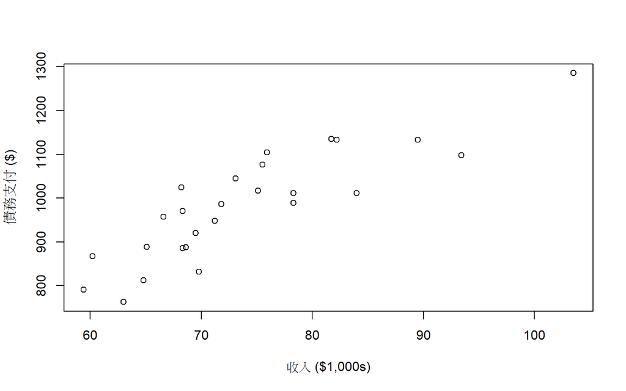

```r
# 使用 debt.payments.df 數據文件來構建散佈圖。
# 使用 plot() 函數創建散佈圖，並且自定義 x 軸和 y 軸的標籤。
plot(debt.payments.df[,"Debt"] ~ debt.payments.df[,"Income"],
     ylab = "債務支付 ($)", xlab = "收入 ($1,000s)")
```

### II. 添加趨勢線

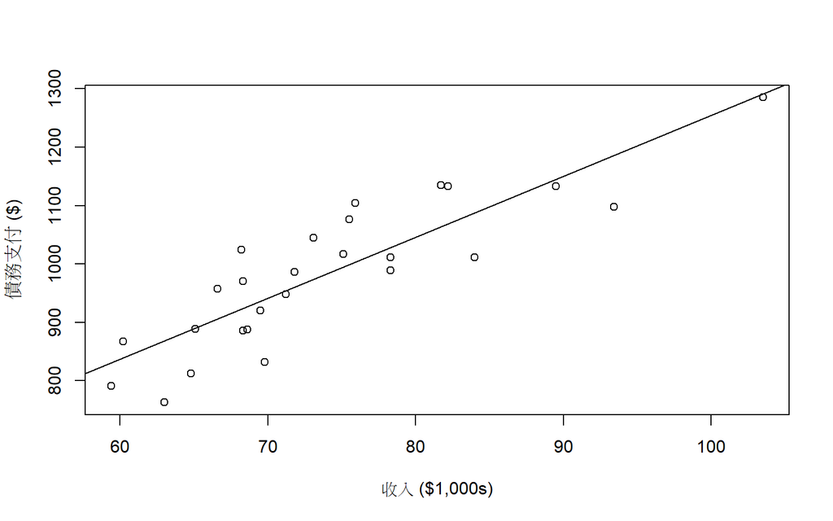

```r
# 使用 debt.payments.df 數據文件來構建散佈圖。
# 使用 plot() 函數創建散佈圖，並且自定義 x 軸和 y 軸的標籤。
plot(debt.payments.df[,"Debt"] ~ debt.payments.df[,"Income"],
     ylab = "債務支付 ($)", xlab = "收入 ($1,000s)")

# 使用 lm() 函數來構建一個簡單的線性回歸模型
# 然後使用 abline() 函數將趨勢線添加到散佈圖中
debt.income.lm <- lm(Debt ~ Income, data = debt.payments.df)
abline(debt.income.lm)
```

### III. 使用 ggplot2 函數構建更精美的散佈圖

```r
# 載入 ggplot2
library(ggplot2)

# 使用 ggplot2 創建帶有趨勢線的散佈圖
debt.income.plot <- ggplot(debt.payments.df, aes(Income, Debt)) +
                    geom_point() +  # 添加數據點
                    geom_smooth(method = "lm", se = FALSE) +  # 添加趨勢線
                    labs(x = "收入 ($1,000s)", y = "債務支付 ($)")  # 添加自定義標籤

# 顯示圖表
print(debt.income.plot)
```

[output not shown]

[output cut: 97 more lines]

[output not shown]

# Chapter 13

Chapter13.xlsx [下載點](https://docs.google.com/spreadsheets/d/1ZkKtaNMsz2UGI0MjJycjSKdwVxVKkTcu/edit?usp=share_link&ouid=110553448349846752071&rtpof=true&sd=true)

## 1.安裝、載入套件&讀檔

```r
# 載入套件
# install.packages(c("openxlsx", "reshape2", "agricolae"))
library(openxlsx)
library(reshape2)
library(agricolae)
# 讀取檔案
file_path <- "D:/college information/R_statistics/Data Files/Chapter13.xlsx" # 更改成您要讀取之xlsx的路徑
sheet_name_1 <- "Public_Transportation" #這裡輸入您要讀取的sheet的名稱
sheet_name_2 <- "TwoFactor_Income" #這裡輸入您要讀取的sheet的名稱
sheet_name_3 <- "Income_Interaction" #這裡輸入您要讀取的sheet的名稱

# 使用read.xlsx函數讀取指定的工作表
public.transportation.df <- read.xlsx(file_path, sheet = sheet_name_1)
two.factor.income.df <- read.xlsx(file_path, sheet = sheet_name_2)
income.interaction.df<- read.xlsx(file_path, sheet = sheet_name_3)

# head
head(public.transportation.df)
```

```
##   Boston    NY    SF Chicago
## 1  12500 12450 11800   10595
## 2  12640 12500 11745   10740
## 3  12600 12595 11700   10850
## 4  12625 12605 11800   10725
## 5  12745 12650 11700   10740
## 6     NA 12620 11575      NA
```

```r
head(two.factor.income.df)
```

```
##            X1 Educational.Services Financial.Services Medical.Services
## 1 High School                   18                 25               26
## 2  Bachelor’s                   35                 45               43
## 3    Master’s                   46                 58               62
## 4       Ph.D.                   75                 90              110
```

```r
head(income.interaction.df)
```

```
##            X1 Educational Financial Medical
## 1 High School          20        27      26
## 2        <NA>          25        25      24
## 3        <NA>          22        25      25
## 4  Bachelor's          30        44      42
## 5        <NA>          35        46      43
## 6        <NA>          34        48      45
```

## 2. One-Way ANOVA; Fisher and Tukey Confidence Intervals

(Replicating Table 13.4 and Table 13.5)

### A. 數據準備

```
首先，我們需要將城市名稱和成本數值進行堆疊。為此，我們使用 reshape2 包中的 melt() 函數來重新配置數據，並將結果儲存為 melted.df。這裡 melt() 函數將數據堆疊成兩列：一列表示城市名稱（City），另一列表示相應的交通成本（Cost）。
```

```r
# 加載reshape2包
library(reshape2)

# 堆疊城市名稱和成本數據
melted.df <- melt(public.transportation.df)
# 將堆疊後的數據列命名
colnames(melted.df) <- c("City", "Cost")

# 查看堆疊後的數據
print(melted.df)
```

```
##       City  Cost
## 1   Boston 12500
## 2   Boston 12640
## 3   Boston 12600
## 4   Boston 12625
## 5   Boston 12745
## 6   Boston    NA
## 7   Boston    NA
## 8   Boston    NA
## 9       NY 12450
## 10      NY 12500
## 11      NY 12595
## 12      NY 12605
## 13      NY 12650
## 14      NY 12620
```

[output cut: 18 more lines]

### B. 建立變異數分析模型(variance model)

```
我們使用 aov() 函數來構建一個變異數分析模型(variance model)，並將該模型儲存為 transit.aov。
這個模型將交通成本 (Cost) 作為應變量，城市 (City) 作為自變量。
```

```r
# 建立變異數分析模型
transit.aov <- aov(Cost ~ City, data = melted.df)
```

### C. 生成 ANOVA 表

```r
# 生成 ANOVA 表
anova_result <- anova(transit.aov)
print(anova_result)
```

```
##           Df   Sum Sq Mean Sq  F value       Pr(>F)
## City       3 13204720 4401573 610.5664 7.955557e-20
## Residuals 20   144180    7209       NA           NA
```

```
使用 anova() 函數來生成 ANOVA 表，該表顯示了不同城市間的成本差異是否具有統計顯著性。

解釋：
  City: P 值（Pr(>F)）小於 0.001，表明城市之間的成本差異具有顯著性。
```

### D. 使用 TukeyHSD 進行多重比較檢驗

```
我們使用 TukeyHSD() 函數來進行 Tukey HSD 檢驗，這是一種多重比較方法，用於比較多個組別之間的均值差異。我們將置信水平（conf.level）設為 95%。
```

```r
# 進行 Tukey 檢驗
tukey_result <- TukeyHSD(transit.aov, conf.level = 0.95)
print(tukey_result)
```

```
## $City
##                 diff        lwr         upr        p adj
## NY-Boston        -37  -172.4791    98.47906 8.694226e-01
## SF-Boston       -902 -1045.9018  -758.09820 7.511769e-13
## Chicago-Boston -1892 -2042.3005 -1741.69947 1.920686e-14
## SF-NY           -865  -993.3435  -736.65649 1.898481e-13
## Chicago-NY     -1855 -1990.4791 -1719.52094 1.920686e-14
## Chicago-SF      -990 -1133.9018  -846.09820 1.325606e-13
##
## attr(,"class")
## [1] "TukeyHSD"  "multicomp"
## attr(,"orig.call")
## aov(formula = Cost ~ City, data = melted.df)
## attr(,"conf.level")
## [1] 0.95
## attr(,"ordered")
## [1] FALSE
```

### E. 使用 LSD.test 進行 Fisher 檢驗

```
R 中沒有直接計算 Fisher 置信區間的函數，
但我們可以使用 argicolae 包中的 LSD.test() 函數來計算 Fisher 的 LSD 檢驗所需的所有值。
```

```r
# 加載 agricolae 包
library(agricolae)

# 進行 Fisher 檢驗
fisher.lsd <- LSD.test(transit.aov, "City")
print(fisher.lsd)
```

```
## $statistics
##   MSerror Df  Mean        CV
##      7209 20 11990 0.7081387
##
## $parameters
##         test p.ajusted name.t ntr alpha
##   Fisher-LSD      none   City   4  0.05
##
## $means
##          Cost      std r       se      LCL      UCL   Min   Max   Q25     Q50
## Boston  12622 87.79237 5 37.97104 12542.79 12701.21 12500 12745 12600 12625.0
## Chicago 10730 90.62284 5 37.97104 10650.79 10809.21 10595 10850 10725 10740.0
## NY      12585 80.40078 8 30.01874 12522.38 12647.62 12450 12700 12545 12600.0
## SF      11720 83.96428 6 34.66266 11647.69 11792.31 11575 11800 11700 11722.5
##              Q75
## Boston  12640.00
## Chicago 10740.00
## NY      12627.50
## SF      11786.25
##
## $comparison
## NULL
##
## $groups
##          Cost groups
## Boston  12622      a
## NY      12585      a
## SF      11720      b
## Chicago 10730      c
##
## attr(,"class")
## [1] "group"
```

## 3. Two-Way ANOVA (No Interaction)

(Replicating Table 13.14)

### A. 重新配置數據

```r
# 使用 melt() 函數重新配置數據
melted2.df <- melt(two.factor.income.df, id.vars = "X1")
# 命名列
colnames(melted2.df) <- c("Education", "Field", "Salary")
```

### B. 建立變異數分析模型(variance model)

```
接著，我們使用 aov() 函數來構建一個加法模型（即沒有交互作用的模型），並將該模型儲存為 income.aov。
這個模型將薪資 (Salary) 作為應變量，教育程度 (Education) 和專業領域 (Field) 作為自變量。
```

```r
# 建立雙因子變異數分析模型
income.aov <- aov(Salary ~ Education + Field, data = melted2.df)
```

### C. 生成 ANOVA 表

```r
# 生成 ANOVA 表
anova_result <- anova(income.aov)
print(anova_result)
```

```
##           Df    Sum Sq    Mean Sq   F value       Pr(>F)
## Education  3 7632.9167 2544.30556 56.575046 8.595367e-05
## Field      2  579.5000  289.75000  6.442866 3.206655e-02
## Residuals  6  269.8333   44.97222        NA           NA
```

```
解釋：
  Education: F 值為 56.5750，P 值（Pr(>F)）小於 0.001，表明教育程度對薪資的影響具有高度顯著性。
  Field: F 值為 6.4429，P 值為 0.03207，表明專業領域對薪資的影響具有顯著性。
  Residuals: 殘差的自由度為 6，Sum Sq 為 269.8。
```

## 4. Two-Way ANOVA (with Interaction)

(Replicating Table 13.17)

### A. 數據清理

```
首先，我們需要清理數據。由於原始數據框 income.interaction.df 的第一列中某些欄位缺少資料，
因此我們使用 c() 和 rep() 函數來創建一個新的列，並替換原始的第一列。
這樣做可以確保每個教育程度的名稱正確地對應於每組數據。
```

```r
# 清理數據，替換第一列
income.interaction.df[, 1] <- c(rep("High School", 3),
                                rep("Bachelor's", 3),
                                rep("Master's", 3),
                                rep("Ph.D.", 3))
```

### B. 重新配置數據

```r
# 使用 melt() 函數重新配置數據，將教育程度、專業領域和薪資值堆疊在一起。
melted3.df <- melt(income.interaction.df, id.vars = "X1")
# 命名列
colnames(melted3.df) <- c("Education", "Field", "Salary")
```

### C. 建立基於交互作用的變異數分析模型

```
接著，我們使用 aov() 函數來構建一個有交互作用的模型，並將該模型儲存為 income2.aov。
這個模型將薪資 (Salary) 作為應變量，並考慮教育程度 (Education)、專業領域 (Field) 及其交互作用。
```

```r
# 構建基於交互作用的方差分析模型
income2.aov <- aov(Salary ~ Education * Field, data = melted3.df)
```

### D. 生成 ANOVA 表

```r
# 生成 ANOVA 表
anova_result <- anova(income2.aov)
print(anova_result)
```

```
##                 Df     Sum Sq    Mean Sq    F value       Pr(>F)
## Education        3 20523.8889 6841.29630 658.520499 3.582203e-23
## Field            2   916.2222  458.11111  44.096257 9.182657e-09
## Education:Field  6   318.4444   53.07407   5.108734 1.659488e-03
## Residuals       24   249.3333   10.38889         NA           NA
```

```
解釋：
  Education: F 值為 658.5205，P 值（Pr(>F)）小於 0.001，表明教育程度對薪資的影響具有高度顯著性。
  Field: F 值為 44.0963，P 值小於 0.001，表明專業領域對薪資的影響具有顯著性。
  教育程度與專業領域之間的交互作用的自由度為 6，Sum Sq 為 318.4，Mean Sq 為 53.1，
    F 值為 5.1087，P 值為 0.001659，表明這個交互作用對薪資的影響也具有統計顯著性。
```

# 參考資料

**Textbook**  
*Jaggia, S., & Kelly, A. (2019). Business statistics: Communicating with numbers (3th ed.). McGraw-Hill Education.*